# Regression Models Course Project

Bi-Ruei, Chiu

## Synopsis

In this report, we analyze the Motor Trend Car Road Tests dataset. And we try to answer the following questions :

- Is an automatic or manual transmission better for MPG ?
- Quantify the MPG difference between automatic and manual transmissions.

## Exploratory Data Anaysis

Firstly, we plot the variable Transmission (0 = automatic, 1 = manual), i.e. **am**, versus Miles/gallon, i.e. **mpg**.

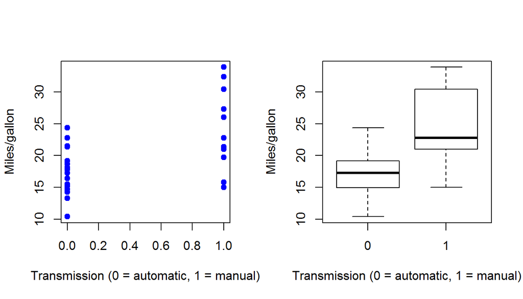

And we can see the mean of manual transmission mode 24.3923077 is larger than automatic transmission mode 17.1473684.Then we try to plot the relation between **mpg** and other 9 variables :

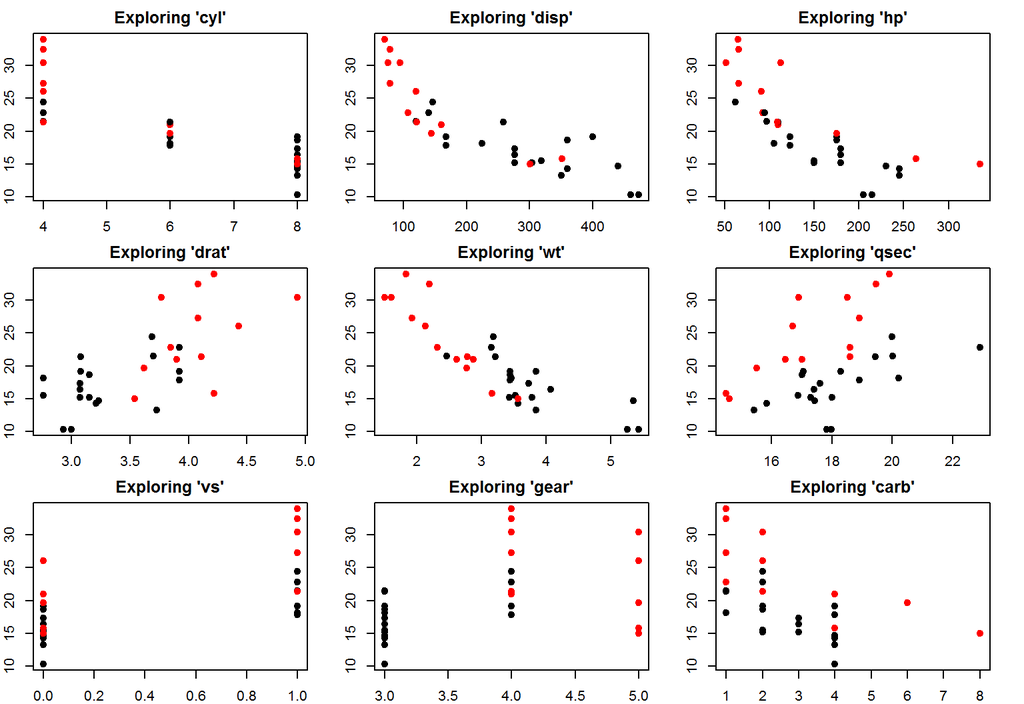

## Model Finding

We try to us linear regression models to fit the variable **am** with variable **mpg** first. And to find the effect of other variables of **mtcars** dataset on **mpg**, we then perform nested model testing by adding add them to **am**. We choose the following models :

- Considering only **am** variable
- Considering **am** and all other variables
- Do nested modeling test with variables

### Linear Model with **am**

```r
# Fit mpg with variable am
fit1 <- lm(mpg ~ am, data = mtcars)
```

The linear model has intercept **17.147** and slope **7.245**. We estimate an expected **7.245** increase in **mpg** for changing from automatic transmission mode to manual mode. The t-test for $H_0 : \beta_{am} = 0$ versus $H_a : \beta_{am} \neq 0$ is significant.

We show the summary of coefficients and the confidence interval of them.

```r
# Summary of coefficients
summary(fit1)$coefficients
```

```
##              Estimate Std. Error   t value     Pr(>|t|)
## (Intercept) 17.147368   1.124603 15.247492 1.133983e-15
## am1          7.244939   1.764422  4.106127 2.850207e-04
```

```r
# Confidence interval of coefficients
confint(fit1)
```

```
##                2.5 %   97.5 %
## (Intercept) 14.85062 19.44411
## am1          3.64151 10.84837
```

Then we plot this linear model and the residual plot and diagnostic of data.

[figure not shown]

We then do diagnostic of this model by finding the change in individual coefficients when the $i^{th}$ point is deleted in fitting it.

```r
# Diagnostic of this model
round(dfbetas(fit1)[, 2],3)
```

```
##           Mazda RX4       Mazda RX4 Wag          Datsun 710
##              -0.159              -0.159              -0.074
##      Hornet 4 Drive   Hornet Sportabout             Valiant
##              -0.133              -0.048              -0.030
##          Duster 360           Merc 240D            Merc 230
##               0.089              -0.234              -0.179
##            Merc 280           Merc 280C          Merc 450SE
##              -0.064              -0.020               0.023
##          Merc 450SL         Merc 450SLC  Cadillac Fleetwood
##              -0.005               0.060               0.216
## Lincoln Continental   Chrysler Imperial            Fiat 128
##               0.216               0.076               0.391
##         Honda Civic      Toyota Corolla       Toyota Corona
##               0.287               0.475              -0.137
##    Dodge Challenger         AMC Javelin          Camaro Z28
##               0.051               0.060               0.120
##    Pontiac Firebird           Fiat X1-9       Porsche 914-2
##              -0.064               0.136               0.075
##        Lotus Europa      Ford Pantera L        Ferrari Dino
##               0.287              -0.423              -0.222
##       Maserati Bora          Volvo 142E
##              -0.468              -0.140
```

### Linear Model with **am** and all other variables

Then we fit variable **mpg** with all other variables without intercept.

```r
# Fit mpg with all variables without intercept
fitall <- lm(mpg ~ . - 1, data = mtcars)
summary(fitall)
```

```
##
## Call:
## lm(formula = mpg ~ . - 1, data = mtcars)
##
## Residuals:
##     Min      1Q  Median      3Q     Max
## -3.5087 -1.3584 -0.0948  0.7745  4.6251
##
## Coefficients:
##       Estimate Std. Error t value Pr(>|t|)
## cyl4  23.87913   20.06582   1.190   0.2525
## cyl6  21.23044   18.33416   1.158   0.2650
## cyl8  23.54297   18.22250   1.292   0.2159
## disp   0.03555    0.03190   1.114   0.2827
## hp    -0.07051    0.03943  -1.788   0.0939 .
## drat   1.18283    2.48348   0.476   0.6407
## wt    -4.52978    2.53875  -1.784   0.0946 .
## qsec   0.36784    0.93540   0.393   0.6997
## vs1    1.93085    2.87126   0.672   0.5115
## am1    1.21212    3.21355   0.377   0.7113
## gear4  1.11435    3.79952   0.293   0.7733
## gear5  2.52840    3.73636   0.677   0.5089
## carb2 -0.97935    2.31797  -0.423   0.6787
## carb3  2.99964    4.29355   0.699   0.4955
## carb4  1.09142    4.44962   0.245   0.8096
## carb6  4.47757    6.38406   0.701   0.4938
## carb8  7.25041    8.36057   0.867   0.3995
## ---
## Signif. codes:  0 '***' 0.001 '**' 0.01 '*' 0.05 '.' 0.1 ' ' 1
##
## Residual standard error: 2.833 on 15 degrees of freedom
## Multiple R-squared:  0.9914, Adjusted R-squared:  0.9817
## F-statistic:   102 on 17 and 15 DF,  p-value: 1.979e-12
```

The variance inflation factors (VIF) of all variables are :

```r
# Variance inflation factors (VIF) of all variables
vif(fitall)
```

```
##              GVIF Df GVIF^(1/(2*Df))
## cyl  126412.01842  3        7.084318
## disp    276.31019  1       16.622581
## hp      161.55546  1       12.710447
## drat    324.86543  1       18.024024
## wt      289.78891  1       17.023187
## qsec   1122.03937  1       33.496856
## vs       14.37896  1        3.791960
## am       16.72505  1        4.089627
## gear    108.48493  2        3.227322
## carb   2300.39703  5        2.168604
```

We then use these information to do the following nested model testing.

### Nested Model Testing by Adding Other Variables

```r
# Fit mpg with variable am
fit2 <- update(fit1, mpg ~ am + wt, data = mtcars)
fit3 <- update(fit1, mpg ~ am + wt + hp, data = mtcars)
fit4 <- update(fit1, mpg ~ am + wt + hp + qsec, data = mtcars)
fit5 <- update(fit1, mpg ~ am + wt + hp + qsec + cyl, data = mtcars)

anova(fit1, fit2, fit3, fit4, fit5)
```

```
## Analysis of Variance Table
##
## Model 1: mpg ~ am
## Model 2: mpg ~ am + wt
## Model 3: mpg ~ am + wt + hp
## Model 4: mpg ~ am + wt + hp + qsec
## Model 5: mpg ~ am + wt + hp + qsec + cyl
##   Res.Df    RSS Df Sum of Sq       F    Pr(>F)
## 1     30 720.90
## 2     29 278.32  1    442.58 76.8460 4.262e-09 ***
## 3     28 180.29  1     98.03 17.0210 0.0003586 ***
## 4     27 160.07  1     20.22  3.5117 0.0726723 .
## 5     25 143.98  2     16.08  1.3964 0.2661265
## ---
## Signif. codes:  0 '***' 0.001 '**' 0.01 '*' 0.05 '.' 0.1 ' ' 1
```

This shows variables **wt** and **hp** has significant effect when added to linear model with **am** variable to form a new one. And **qsec** has less effect when it is added to this aforementioned $4^{th}$ model. While adding one more **cyl** variable, the resulted $5^{th}$ model has P-value 0.2661265 which failed to reject the null hypothesis $4^{th}$ and $5^{th}$ model is same.

## Uncertainty and Inference

We then do two group T tests of mtcars using **mpg** versus transmission model variable **am**.

```r
tst <- t.test(mpg ~ am, paired = FALSE, data = mtcars)
tst
```

```
##
##  Welch Two Sample t-test
##
## data:  mpg by am
## t = -3.7671, df = 18.332, p-value = 0.001374
## alternative hypothesis: true difference in means is not equal to 0
## 95 percent confidence interval:
##  -11.280194  -3.209684
## sample estimates:
## mean in group 0 mean in group 1
##        17.14737        24.39231
```

Again, since the P-value of null hypothesis is **0.0013736** which is less than 0.05. So it shows strong evidence against the null hypothesis.

## Summary

We can conclude that :

- **Manual** transmission mode is better for performance in Miles/(US) gallon.
- The mean of manual transmission mode **24.3923077** is larger than automatic transmission mode **17.1473684**.